# Texas Flood Exposure Analysis

A spatial and statistical assessment of flood risk across Texas counties, 2019–2024

Author

Maya Arnott

Published

March 23, 2026

## Overview

This project quantifies flood exposure and risk across Texas’s 254 counties over the period 2019–2024, combining live government data sources, GIS spatial analysis, hydrological frequency modeling, and regression to produce a reproducible county-level flood risk index.

The analysis is split across two Python modules:

- **`texas_flood_analysis.py`** — data pipeline, spatial joins, and visualizations
- **`risk_modeling.py`** — flood frequency distributions, regression modeling, and the final risk index

All data is either fetched programmatically from public APIs at run time or from github repositories after requesting access.

## Data Sources

| Source | Data | Access |
| --- | --- | --- |
| FEMA OpenFEMA API | NFIP flood insurance claims by county, 2019–2024 | Public REST API |
| USGS NWIS | Annual peak streamflow, full historical record | Public REST API |
| Census TIGER | County boundaries (254 Texas counties) | `pygris` |
| Robbie M Parks and Victoria D Lynch | PRISM County-Level Precipitation Data | Github Download upon Request |
| Multi-Resolution Land Characteristics (MRLC) Consortium | Impervious surface % (2019) | Public download |
| Census ACS 5-year (2022) | Median household income by county | Public REST API |

## Part 1 — Flood Exposure (2019–2024)

### FEMA NFIP Claims

The Federal Emergency Management Agency’s National Flood Insurance Program (NFIP) publishes redacted flood insurance claims through the OpenFEMA API. Each record contains the date of loss, county code, and amounts paid on building and contents claims. These were aggregated to the **county-year** level, with one row per county per year, giving total claim counts and total dollars paid out as the primary measure of realized flood damage.

24,732 claim records were retrieved for Texas across 2019–2024.

### USGS Peak Streamflow

USGS maintains a network of river gauges across Texas. Annual peak flow readings were pulled from the NWIS database. Because the peak flow endpoint does not include coordinates, a second API call to the USGS site service retrieved lat/lon for each gauge, which were then spatially joined to county polygons, assigning each gauge to whichever of the 254 county boundaries it falls within. This produced a county-year count of above-median flood events as a physical corroborating signal alongside the insurance claims.

### Composite Exposure Score

The FEMA and USGS data were combined into a single composite score per county-year:

$$\text{Exposure Score} = 0.5 \cdot \tilde{n}_{\text{claims}} + 0.3 \cdot \widetilde{\text{payout}} + 0.2 \cdot \tilde{n}_{\text{gauge events}}$$

### Maps

The grid below shows one choropleth per year. Color encodes the composite exposure score, where darker blue indicates higher relative flood exposure within that year.

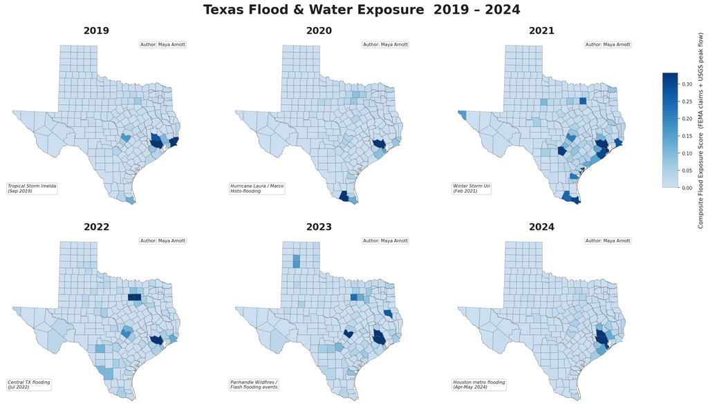

Texas Flood Exposure 2019–2024. Each panel shows the composite score derived from FEMA NFIP claims and USGS peak streamflow gauge events. Dashed annotation boxes note the dominant meteorological event for each year.

Notable patterns:

- **2019**: Southeast Texas (Harris, Jefferson, Orange counties) shows elevated exposure driven by Tropical Storm Imelda, which dropped over 40 inches in parts of the region.
- **2021**: The statewide signal from Winter Storm Uri is visible across central and eastern counties, reflecting widespread pipe failures and subsequent flood claims rather than riverine flooding alone.
- **2024**: The Houston metropolitan area reemerges as the dominant exposure cluster following the April through May flooding events.

### Statewide Trend

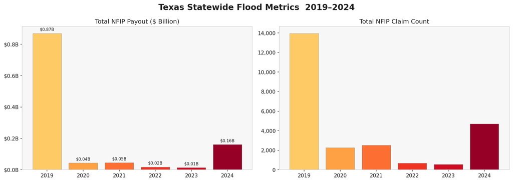

### County Time Series

The twelve counties with the highest cumulative NFIP payout across 2019–2024 are shown below. Harris County (Houston) dominates by absolute dollar value, but note that smaller Gulf Coast counties such as Jefferson and Orange show disproportionately high payouts relative to their population, indicating structural flood exposure rather than solely claim volume.

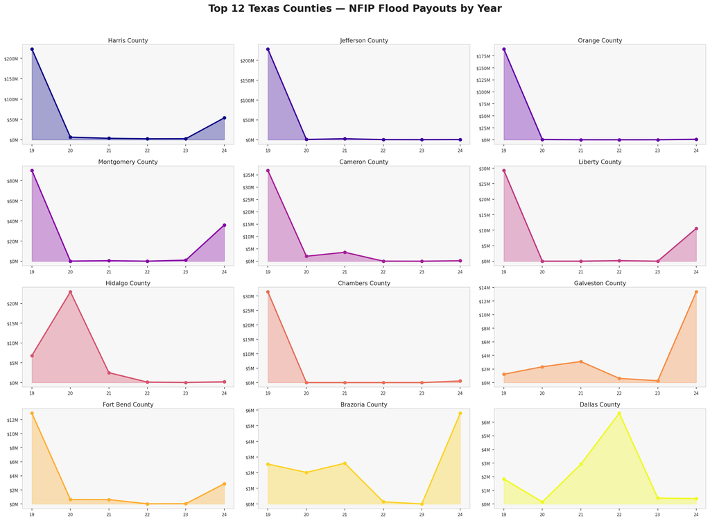

## Part 2 — Flood Frequency Analysis

### Motivation

Choropleth maps of historical claims show where damage *has* occurred. Flood frequency analysis asks a different question: given the physical hydrology of each county, how large a flood should we expect at a given return period? This is the core methodology behind FEMA Flood Insurance Rate Maps and private climate risk scores.

### Method

The full historical USGS peak streamflow record for Texas, instead of only using 2019–2024, was retrieved to maximize the length of record available for distribution fitting. Frequency analysis requires ideally 30–50+ years of data to constrain the tail of the distribution.

For each county, annual maximum peak flows were extracted (one value per year, pooled across all gauges within the county). Two distributions were fitted:

**GEV (Generalised Extreme Value)** — the theoretically justified model for block maxima such as annual peak flows, derived from extreme value theory. The GEV has three parameters: location $\mu$, scale $\sigma$, and shape $\xi$, where the shape parameter determines whether the tail is bounded (Weibull, $\xi < 0$), light (Gumbel, $\xi = 0$), or heavy (Fréchet, $\xi > 0$).

**Log-Pearson III (LP3)** — the US federal standard for flood frequency analysis, defined in USGS Bulletin 17C. A Pearson III distribution is fitted to the log-transformed annual maxima.

Both models were fitted by maximum likelihood. The better fit was selected by **AIC** (Akaike Information Criterion):

$$\text{AIC} = 2k - 2\ln(\hat{L})$$

where $k = 3$ parameters and $\hat{L}$ is the maximized likelihood. Lower AIC indicates a better fit penalized for model complexity.

From the winning distribution, Q10, Q50, and Q100 return period flows were estimated — the flow magnitude with a 1-in-10, 1-in-50, and 1-in-100 annual exceedance probability respectively.

### Results

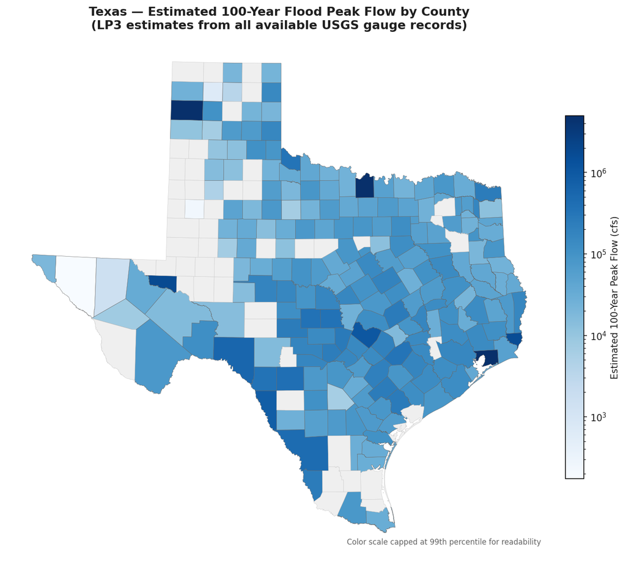

The frequency curves below show LP3 fits for the ten counties with the most gauge observations. Empirical plotting positions follow the Weibull formula $p = m / (n + 1)$ where $m$ is rank in ascending order.

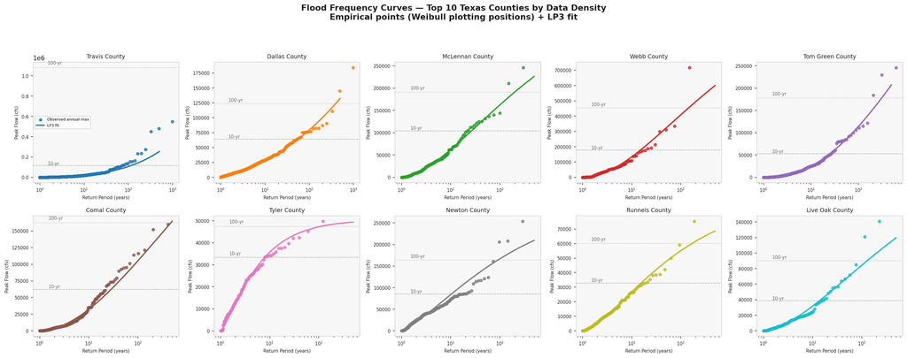

LP3 flood frequency curves for the ten highest-data-density Texas counties. Points show empirical annual maxima (Weibull plotting positions); lines show the fitted Log-Pearson III distribution. Horizontal dashed lines mark the estimated 10-year and 100-year return flows.

After evaluating both methods, LP3 was preferred to GEV because the GEV fits produced unstable upper-tail estimates for several Texas counties. LP3 gave a more credible graphical match to the observed annual maxima while still capturing the strong right-skew typical of flood-flow data.

## Part 3 — Regression Model

### Features

Five predictors were assembled at the county-year level:

[output not shown]

The target variable is $\log(1 + \text{claim count})$ — the log transform stabilizes the right-skewed distribution of claim counts, where most county-years have zero or few claims but a small number have thousands.

### OLS

An OLS model with heteroscedasticity-robust standard errors (HC3) was fitted to the full 2019–2024 panel. HC3 standard errors are preferred here because variance in claim counts is substantially higher in flood-prone counties than in dry ones — a classic case of heteroscedasticity.

$$\log(1 + y_{it}) = \beta_0 + \beta_1 \cdot \text{precip\_anom}_t +
\beta_2 \cdot \text{imperv}_i + \beta_3 \cdot \text{income}_i +
\beta_4 \cdot \log Q10_i + \beta_5 \cdot \text{trend}_t + \varepsilon_{it}$$

**In-sample R² = 0.464.** The five features explain about 46.4% of variance in log claim counts.

### Random Forest

The same features were passed to a Random Forest with 300 trees, maximum depth 6, and minimum 5 samples per leaf. **5-fold cross-validated R² = 0.361 ± 0.083, and the temporal holdout (2023–2024) R² = 0.603.**

The higher in-sample R² (≈0.748) reflects the model’s fit to the training data and illustrates that Random Forest can flexibly capture non-linear and interaction effects that OLS cannot. The improvement over OLS indicates two things: 1. Relationships between features and claim counts are non-linear. For example, impervious surface likely has little effect until it crosses a threshold, beyond which runoff and claims increase sharply. 2. Interaction effects matter: a county that is both highly paved and experiences an anomalously wet year sees disproportionately more claims than either factor alone would predict.

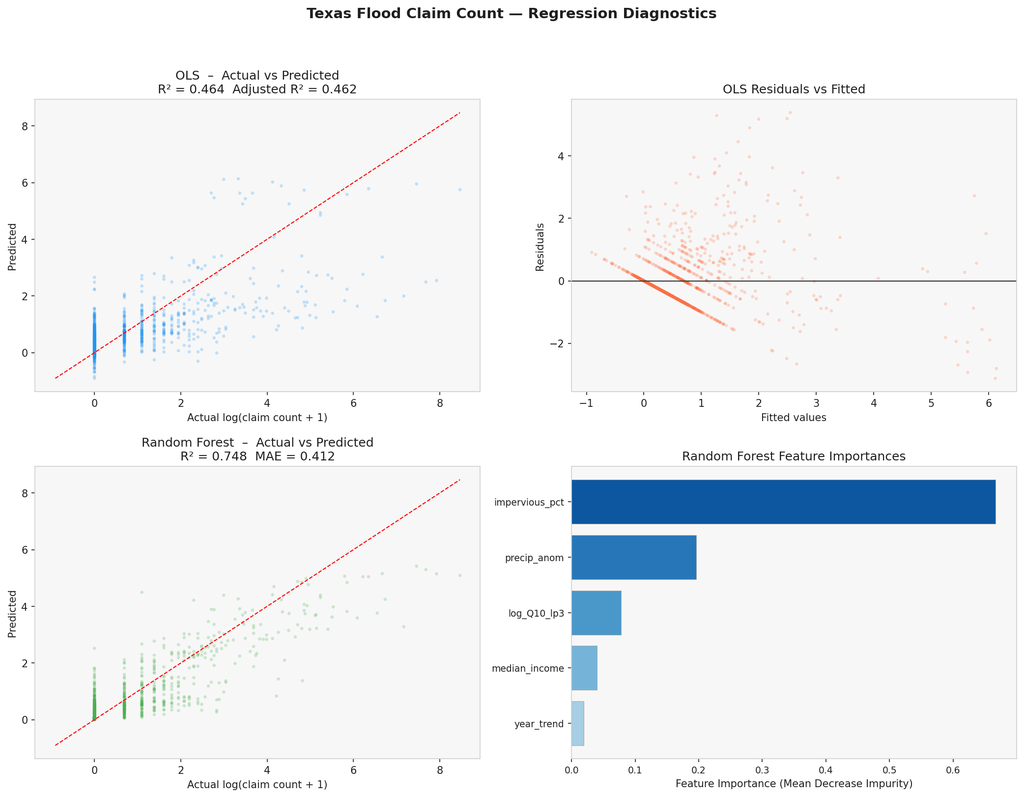

Regression diagnostics. Top row: OLS actual vs predicted and residual plot. Bottom row: Random Forest actual vs predicted and feature importances. The fan shape in the OLS residual plot confirms heteroscedasticity — variance increases with fitted values, consistent with a skewed claim distribution.

## Part 4 — Temporal Holdout Validation

### Why Temporal Holdout Matters

The 5-fold cross-validation above splits data randomly. This means a fold can train on 2022 and 2023 data and then predict 2020 — leaking future information into training. For a forecasting application, this is too optimistic: in practice a model trained on historical data will only ever be applied to future years it has never seen.

A temporal holdout enforces the correct discipline: train exclusively on 2019–2022, then evaluate on 2023–2024 as if making genuine out-of-sample predictions.

```
Training:  2019–2022  (~1,016 county-year rows)
Test:      2023–2024  (~508 county-year rows)
```

### Results

[output not shown]

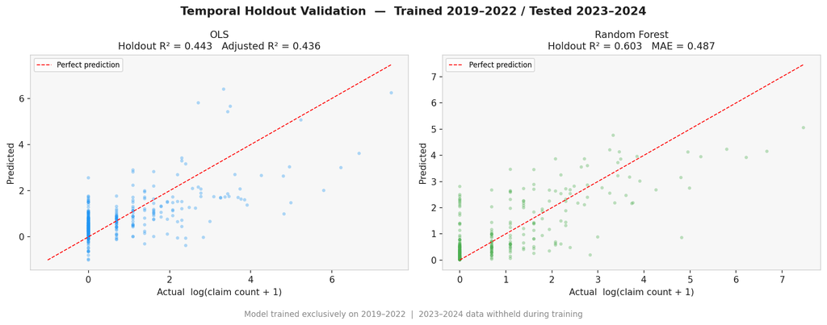

Temporal holdout validation. Both models trained on 2019–2022 only and evaluated on withheld 2023–2024 data.

### Interpretation

The OLS holdout R² of 0.443 indicates that the linear relationships learned from 2019–2022 generalize reasonably well to new years. While some degradation is expected, the linear model still retains much of its explanatory power.

The Random Forest achieved a holdout R² of 0.603, which is an improvement over its 5-fold CV R² of 0.361. This suggests that the non-linear patterns it captured, particularly the interaction between impervious surface and flood hazard, are genuine and temporally stable rather than artifacts of overfitting to specific training years.

## Part 5 — Final Risk Index

A county-level risk index was constructed by combining four normalized dimensions:

$$\text{Risk Index} = 0.40 \cdot \text{Exposure} + 0.35 \cdot \text{Hazard} +
0.15 \cdot \text{Imperviousness} + 0.10 \cdot \text{Vulnerability}$$

where:

- **Exposure** = total NFIP claims across 2019–2024, normalized 0–100
- **Hazard** = estimated Q100 return period flow, normalized 0–100
- **Imperviousness** = mean impervious surface %, normalized 0–100
- **Vulnerability** = inverse of median household income, normalized 0–100 (lower income = higher vulnerability)

The full table is saved to `outputs/texas_risk_score_final.csv`.

## Limitations & Next Steps

**Current limitations:**

**Next Steps:**

1. Add a binary FEMA disaster declaration indicator per county-year as a feature, which is publicly available and would directly encode whether a major event occurred
2. Implement a proper train/test split by event rather than by year, treating each named storm as a holdout event
3. Incorporate NLCD impervious surface rasters over the years directly to enable time-varying land cover from the 2001, 2006, 2011, 2016, and 2021 NLCD vintages

## Reproducibility

```bash
# Run in order
python texas_flood_analysis.py
python risk_modeling.py
```

All outputs are written to `./outputs/`. The Quarto document can be rendered with:

```bash
quarto render texas_flood_analysis.qmd
```